# Panorama des techniques d’analyse textuelle

## De quoi s'agit-il ?

**L'analyse textuelle ou text-mining** est l'étude statistique des données textuelles (document, paragraphe, phrase, mots, caractères..). Elle consiste à **structurer**, décrire les unités sous la forme de **vecteurs numériques**, puis à utiliser des techniques (traditionnelles) de data-mining sur ces vecteurs. La **lexicométrie** est l'analyse du lexique, tandis que l'analyse sémantique ou **natural language processing** permet d'aller plus loin dans la compréhension du message.

Le texte brut est **difficile à traiter** : très irrégulier, avec de la ponctuation, des fautes d'orthographes, des fautes de frappes, un même mot peut avoir plusieurs formes, un même mot peut référer à différents concepts (polysémie) et différents mots peuvent décrire la même chose (synonymie)…

## Des applications multiples

- Analyse lexicale (**léxicométrie**) : extraction d'information, catégorisation de texte en déterminant des sujets dans un corpus et en classer les documents du corpus selon ces sujets par exemple, indexation des documents (moteurs de recherche), construction de résumé..
- **Analyse grammaticale**, sémantique : identification d'éléments sémantiques dans un texte (entitées, propriétés, relations…), utile pour l'étuder du sentiment/opinion…
- Aller plus loin dans le traitement du **language naturel** et de la construction des phrases peut avoir également des intérêts : intelligence artificielle, raisonnement par analogie, prédire la suite d'un texte…

La première application nous intéresse le plus, nous aborderons très succintement la deuxième.

## Plan de la présentation

De la préparation à l'utilisation des données textuelles :

- Le **prétraitement** et la "fouille de texte"
- L'utilisation de variables textuelles pour la **clusterisation** de texte et l'**économétrie**
- L'**analyse sémantique** (introduction)

Les différentes étapes seront illustrées avec du code **R**, en particulier la librairie `tm` permet une bonne entrée en matière. L'équivalente sous python est `nltk`. Quelques utilitaires ont été testés pour l'orthographe et l'étiquetage.

Des logiciels clé en main sont disponibles pour le français (**Iramuteq**, **r.temis**), ils sont très pratiques pour le prétraitement et la construction du lexique (**exportable**), les applications peuvent être ensuite limitées.

## Le prétraitement

## Le prétraitement en résumé

- Le formatage
- L'orthographe
- La création du lexique
- Le bilan lexical

*Les exemples suivants portent sur l'enquête victimation, d'où un vocabulaire parfois fleuri..*

## Formatage et orthographe

## Le formatage

En analyse textuelle, on appelle **corpus** l'ensemble des **documents** textes qui seront soumis à l'analyse.

```r
myCorpus0 <- Corpus(VectorSource(police),list(language = "french"))
myCorpus0
```

```
## <<VCorpus>>
## Metadata:  corpus specific: 0, document level (indexed): 0
## Content:  documents: 6261
```

```r
myCorpus0[[2]][1]
```

```
## $content
## [1] "DES CHOSES SONT PUNIS SEVEREMENT D AUTRES PAS ASSEZ TROP D INEGALITE DE TRAITEMENT"
```

## Le formatage

Afin de faciliter l'analyse, le texte doit être **nettoyé** et homogénéisé (normalisé).

C'est à l'utilisateur de définir le niveau de traitement lexical du corpus : passage des termes en minuscule, suppression de la ponctuation, suppression des nombres, suppression des espaces en trop… La plupart des traitements sont classiques et intégrés à la librairie.

```r
myCorpus <- tm_map(myCorpus0, tolower)
myCorpus <- tm_map(myCorpus, removePunctuation)
myCorpus <- tm_map(myCorpus, removeNumbers)
myCorpus <- tm_map(myCorpus, stripWhitespace)
myCorpus[[2]][1]
```

```
## [1] "des choses sont punis severement d autres pas assez trop d inegalite de traitement"
```

## Le formatage

Il est possible de définir ses propres fonctions de traitement.

```r
trim <- function (x) gsub("^\\s+|\\s+$", "", x)
myCorpus <- tm_map(myCorpus, trim)
```

Il faudrait par exemple écrire une fonction qui remplace les apostrophes par des espaces.

## L'orthographe

Pour détecter les mots mal orthographiés, on peut utiliser un **correcteur orthographique**, tel que aspell. Une fois installé, cet utilitaire peut être utilisé par le biais d'une fonction R.

```r
aspell(as.factor("accuser"),program="aspell",control="--master=fr_FR")
test<-aspell(as.factor("acuser"),program="aspell",control="--master=fr_FR")
test$Suggestions
```

```
## [[1]]
##  [1] "accuser" "accuse"  "accusé"  "ac user" "ac-user" "accuses" "accusés"
##  [8] "abuser"  "amuser"  "accusée" "causer"
```

## L'orthographe

Les suggestions ne sont pas forcément pertinentes surtout en cas de corpus très spécifique (ici les insultes), on peut supposer qu'il existe une version correctement orthographiée dans le reste du lexique, on peut donc chercher le mot le plus proche par **fuzzy matching** (distance de **Levenshtein**)

```r
agrep("conard", c("connard", "batard"), max = 2, value = TRUE)
```

```
## [1] "connard"
```

```r
agrep("acusait", c("accusait", "abusait"), max = 2, value = TRUE)
```

```
## [1] "accusait" "abusait"
```

## L'orthographe

La distance de Levenshtein est une distance mathématique donnant une mesure de la similarité entre deux chaînes de caractères. Elle est égale au nombre minimal de caractères qu'il faut **supprimer**, **insérer** ou **remplacer** pour passer d'une chaîne à l'autre.

Particulièrement utile si le champ lexical est spécifique (ici les insultes). Problème : deux mots de sens très éloignés peuvent être proches en termes de lettres.

Une autre solution serait d'utiliser la **phonétique** pour corriger les mots qui sont mal orthographiés mais se prononcent de la même façon que le mot correctement orthographié.

```r
library(RecordLinkage)
soundex(x<-c('accusait','acusait','abusait'))
```

```
## [1] "A223" "A223" "A123"
```

## L'orthographe

Une possibilité plus avancée pour corriger automatiquement le mot si le nombre d'erreurs et **générant automatiquement des candidats** est d'utiliser comme dictionnaire un texte très important (un million d'occurrences). On utilise ensuite la formule de Bayes pour estimer la probabilité d'avoir écrit un mot au lieu d'un autre (Peter Norvig, Google), en prenant compte la distribution des mots dans la langue.

```r
sorted_words <- names(sort(table(strsplit(tolower(paste(readLines("big.txt"),
collapse = " ")), "[^a-z]+")), decreasing = TRUE))
correct <- function(word) { c(sorted_words[ adist(word, sorted_words) <=
min(adist(word, sorted_words), 2)], word)[1] }
correct("telelephone")
```

```
## [1] "telephone"
```

```r
sorted_words <- names(sort(table(strsplit(tolower(paste(readLines("big_french.txt"),
collapse = " ")), "[^a-z]+")), decreasing = TRUE))
```

## L'orthographe

```r
correct("conard")
```

```
## [1] "consid"
```

```r
correct("acusait")
```

```
## [1] "abusait"
```

```r
correct("anenantir")
```

```
## [1] "anenantir"
```

```r
correct("femm")
```

```
## [1] "femme"
```

## L'orthographe

Cette approche nécessite un très large corpus (et dans le cas des insultes, un corpus les intégrant..). Nos tests ne sont pas très concluants sur un petit corpus (mais facile à améliorer).

L'utilitaire **Google Suggest** (via un navigateur et internet), permet aussi de retrouver une orthographe en considérant les requêtes suggérées. Attention ce sont des requêtes qui sont suggérées, elles peuvent donc être composées de plusieurs mots.

## L'orthographe

```r
fix<-function(word){
url=paste("http://google.fr/complete/search?output=toolbar&q=",word,sep="")
lookUp <- URLencode(url) #What do you think this does?
result <- readLines(lookUp, warn="F") #en xml puisque c'est l'option retenue dans la requête
require(XML)
xtree <- xmlInternalTreeParse(result)
suggestNodes <- getNodeSet(xtree, "//suggestion[@data]")
suggests <- lapply(suggestNodes, function(x) xmlAttrs(x)['data'])
suggests[[1]]}
fix("conard")
```

```
##                 data
## "conard high school"
```

```r
fix("conasse")
```

```
##                data
## "conasse streaming"
```

```r
fix("aggression")
```

```
##         data
## "aggression"
```

## L'orthographe

Une fois le mot corrigé, il est possible de remplacer toutes les occurrences mal orthographiées par une fonction de `stringi`

```r
word <- c('conard')
corr <- c('connard')

library(stringi)
#myCorpus <- tm_map(myCorpus, function(x) stri_replace_all_fixed(x, word, corr, vectorize_all = FALSE))
```

## La création du lexique

## La création du lexique en étapes

- Eliminer les mots de liaison (stop words)
- Remplacer chaque mot par sa racine+ (stems)
- Pondérer les termes (ex: TF)
- Détecter des patterns (mot composé, groupe.)
- Sélectionner les meilleurs termes (filtrage, thématiques)
- Convertir les documents en vecteurs pour une future utilisation

## Le lexique, définition

On l'appelle aussi **dictionnaire** ou **vocabulaire**

- Il permet d'obtenir une forme canonique du document
- Il s'agit d'une liste de mots simples ou composés représentatifs d'un domaine ou plusieurs domaines, "normalisés" (analyse morphologique…)
- Il peut contenir des entités nommées (Puy de Dôme, Mont Blanc), et posséder des informations linguistiques additionnelles (étiquettes)
- Il est différent mais voisin du concept d'ontologie
- Sa construction manuelle est difficile mais essentielle

## Les mots "vide"

La suppression des **mots vides**, ou **mots outils** (stopwords) permet de réduire le lexique. En effet, ces termes ne sont pas discriminants parmi les documents. Et si on ne s'intéresse pas à la sémantique, ils n'apportent aucune information sur les thèmes abordés.

```r
stopwords("french")[1:15]
```

```
##  [1] "au"   "aux"  "avec" "ce"   "ces"  "dans" "de"   "des"  "du"   "elle"
## [11] "en"   "et"   "eux"  "il"   "je"
```

## Les mots "vide"

On peut facilement ajouter ou retirer des mots de cette liste.

```r
myCorpus <- tm_map(myCorpus, removeWords, stopwords('french'))
#rq etc n'est pas considéré comme un stopword, on va l'ajouter
myStopwords <- c(stopwords('french'), "etc")
myStopwords <- setdiff(myStopwords, c("pas", "de"))
myCorpus <- tm_map(myCorpus, removeWords,myStopwords)
myCorpus <- tm_map(myCorpus, PlainTextDocument)
myCorpus[[2]][1]
```

```
## $content
## [1] " choses  punis severement  autres  assez trop  inegalite  traitement"
```

## L'analyse morphologique

L'analyse morphologique des termes peut se faire suivant deux concepts : la **lemmatisation** ou la **racinisation**

**Lemmatisation** ~ forme canonique

- livre, livres [livre]
- mange, mangera, mangeaient, mangeant, [manger]

Nécessite une grammaire, généralement entrée de référence en dictionnaire, empêche que des formes très proches n'ayant rien à voir soient regroupées (grand, gras, grave)

**racinisation** ~ racine + dérivation [préfixe/suffixe]

- produire, production, productivité [produc]
- Calculé par un algorithme (Stemmer)

## L'analyse morphologique

La racinisation est réalisée par le paquet `SnowballC` (algorithme de Porter), elle est plus rapide et pratique que la lemmatisation mais peut être approximative (la lemmatisation peut se faire avec treeTagger par exemple, cf. partie analyse sémantique pour un exemple d'utilisation).

```r
myCorpusLem <- tm_map(myCorpus, stemDocument, language = "french")
myCorpusLem[[2]][1]
```

```
## $content
## [1] " chos  pun sever  autr  assez trop  inegalit  trait"
```

## Point sur le stemming du package "snowballC"

On utilise un certain nombre de règles pour identifier racine et terminaison.

Par exmple la racine comprendra les trois premières lettres si le mot commence par deux voyelles, ou elle ira jusqu'à la deuxième voyelle incluse sauf si c'est la dernière lettre du mot.

Exemple : - aimER - adoRER - voLER

Les règles appliquées dépendent de la langue considérée.

## Lisibilité du lexique

Après racinisation, on peut compléter les racines (mais toutes les formes admettant la même racine seront représentées par le même terme).

```r
stemCompletion('femm',dictionary=myCorpus)
```

```
##     femm
## "femmes"
```

## L'approche "sac de mots"

Le pré-traitement étant effectué, on peut construire le tableau de contingence ou matrice termes documents, ou les différents termes du lexique présent dans le corpus correspondent aux lignes et les documents aux colonnes (ou la matrice documents termes qui est la transposée).

Dans cette représentation, les documents sont assimilés à des sacs de mots (**bag of words**), l'ordre n'a donc pas d'importance. L'analyse sémantique est assez limitée dans ce type d'approches.

```r
myDtmUnigram <- TermDocumentMatrix(myCorpus)
as.matrix(myDtmUnigram)[1:3,1:4]
```

```
##            Docs
## Terms       character(0) character(0) character(0) character(0)
##   aasez                0            0            0            0
##   abandon              0            0            0            0
##   abandonne            0            0            0            0
```

## La matrice termes x documents dans R

Remarque la fonction `TermDocumentMatrix` est très pratique car elle peut être totalement paramétrée pour prendre en charge le prétraitement, mais s'il est recommandé de procéder étape par étape pour ajuster les listes de mots outils etc…

```r
StemFrench<- function(a)  stemDocument(a, language = "french")

myDtmUnigram <- TermDocumentMatrix(myCorpus0, control = list(tolower = TRUE,
                                                  removePunctuation = list(preserve_intra_word_dashes = TRUE),
                                                  removeNumbers = TRUE,
                                                  stripWhitespace = TRUE,
                                                  stemming= StemFrench,
                                                  stopwords = c(stopwords('french'), "etc"),
                                                  minDocFreq=5,
                                                  wordLengths= c(2, Inf)))
```

## Pondération des termes

Par défaut, cette matrice représente le **nombre d'occurrences** d'un mot dans un document (les mots fréquents ont du poids), mais on pourrait replacer ce nombre par un score binaire (absence ou présence : **tableau lexical entier**) ou un autre score d'importance du mot dans le document.

La lexicométrie ou la statistique lexicale permettent touefois de répondre aux questions suivantes : « quels sont les textes les plus semblables en ce qui concerne le vocabulaire et la fréquence des formes utilisées ? Quelles sont les formes qui caractérisent chaque texte, par leur présence ou leur absence ? ». Mais on ne peut aller beaucoup plus loin dans l'interprétation du message.

## Normalisation de la matrice des termes

TF (term frequency) : nombre d'occurrences d'un terme \(t\) dans un document \(d\)

DF (document frequency) : nombre d'occurrences d'un document \(d\) avec le terme \(t\) dans le corpus \(D\) : \[DF(t,d)=\frac{|\{d \in D : t \in d\}|}{|D|}\]

IDF (inverse document frequency) : un terme qui apparaît dans peu de documents est un meilleur discriminant qu'un terme qui apparaît dans tous les documents (matrice idf).

\[IDF(t,D)= log {DF}^{-1}=log \frac{|D|}{|\{ d \in D : t \in d\}|}\]

## TF-IDF

TF-IDF : mesure l'importance d'un terme dans un document relativement à l'ensemble des documents : si un mot apparait souvent dans un texte mais pas dans les autres, alors le score est élevé ; s'il apparait peu dans le document ou s'il apparait souvent dans tous les documents, alors son score est faible.

Les pondérations **tf-idf** sont souvent utilisées par les moteurs de recherche pour classer les documents par pertinence en fonction de la requête d'un utilisateur. Pour établir un rang, il suffit, pour un document, de sommer les tf-idf pour chaque terme composant une requête.

C'est aussi un moyen d'enlever les mots vides ou communs, donc particulièrement utile pour la construction de résumé et la classification.

## Réduire le lexique

La lemmatisation/racinisation et enlever les mots vides avaient déjà permis de réduire considérablement le lexique, mais on peut également utiliser les pondération pour réduire encore le lexique. Par exemple, en excluant les termes trop rarement représentés via l'option `minDocFreq` ou en calculant la pondération tfidf par terme et en éliminant les termes avec un score trop faible.

En effet, le nombre de mots du lexique final détermine la dimension de l'espace, d'où la nécessité de garder un lexique contraint pour l'utilisation ultérieure de la matrice.

## Le bilan lexical

A partir de cette matrice, on peut réaliser un certain nombre de statistiques descriptives. Par exemple, à partir de la matrice des occurrences, on peut considérer les mots les plus fréquents :

```r
findFreqTerms(myDtmUnigram, lowfreq=100)
```

```
##  [1] "appel"     "assez"     "besoin"    "bon"       "certain"
##  [6] "chos"      "dan"       "delinqu"   "deplacent" "effect"
## [11] "etre"      "fair"      "fait"      "faut"      "font"
## [16] "gen"       "jam"       "manqu"     "moyen"     "nombreux"
## [21] "person"    "petit"     "peu"       "peur"      "plus"
## [26] "polic"     "polici"    "presenc"   "present"   "problem"
## [31] "quand"     "quarti"    "repress"   "rien"      "toujour"
## [36] "travail"   "trop"      "viennent"  "voit"
```

## Le bilan lexical

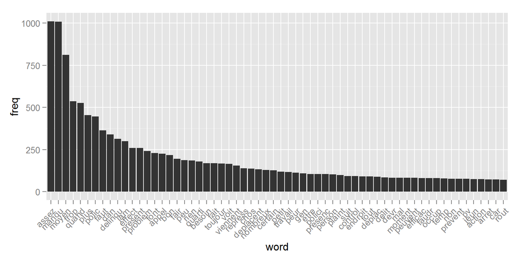

```r
library(ggplot2)
termFrequency <- rowSums(as.matrix(myDtmUnigram))
wfU <- data.frame(word=names(termFrequency), freq=termFrequency)
wfU2<-wfU <- subset(wfU, freq>70 )
wfU2$word <- factor(wfU$word, levels = wfU[order(-wfU$freq), "word"])
ggplot(data=wfU2,aes(word, freq)) + geom_bar(stat="identity") + theme(axis.text.x=element_text(angle=45, hjust=1))
```

## Les similarités

Il est possible à partir de cette matrice où les termes ou les documents peuvent être représentés sous forme de vecteurs, de calculer la similarité entre deux documents, deux termes, un document et un terme..

Cela permet par exemple de retrouver des associations fréquentes de mots.

```r
findAssocs(myDtmUnigram, 'abus', 0.30)
```

```
## $abus
## pouvoir
##    0.35
```

## Les similarités

On peut aussi filtrer pour retrouver le contexte d'utilisation d'un terme.

```r
filt<-tm_filter(myCorpus,FUN= function(x) any(grep("traitement", content(x))))
filt[[1]][1]
```

```
## $content
## [1] " choses  punis severement  autres  assez trop  inegalite  traitement"
```

Mais on peut vouloir traiter les "expressions" de façon plus systématique

## Les expressions

L'étude du lexique peut nous amener à répérer des associations de mots systématiques. On peut vouloir les considérer comme une seule forme ou "token", on parle alors de **bigrammes** pour les couples de termes (ngrammes en généralisant).

```r
library(RWeka)
BigramTokenizer <-function(x) NGramTokenizer(x, Weka_control(min = 2, max = 2))

myDtmBigram <- TermDocumentMatrix(myCorpus, control = list(tokenize = BigramTokenizer))
findFreqTerms(myDtmBigram, lowfreq=50)
```

```
##  [1] "a besoin"         "appelle viennent" "assez moyens"
##  [4] "assez nombreux"   "bon moment"       "jamais quand"
##  [7] "manque effectif"  "manque effectifs" "manque moyen"
## [10] "manque moyens"    "quand a"          "quand appelle"
## [13] "quand faut"
```

## Les expressions

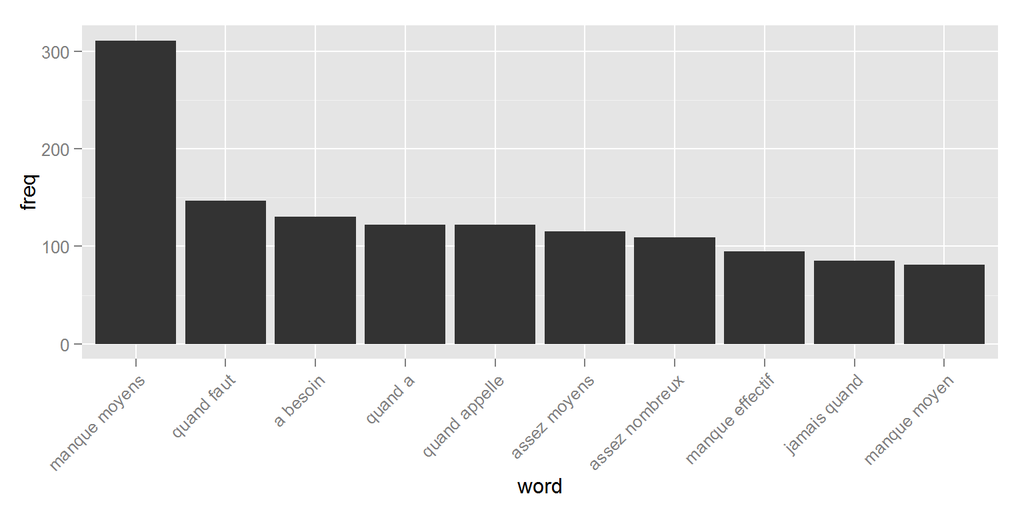

```r
library(ggplot2)
termFrequency <- rowSums(as.matrix(myDtmBigram))
wfB<- data.frame(word=names(termFrequency), freq=termFrequency)
wfB2<-wfB <- subset(wfB, freq>70 )
wfB2$word <- factor(wfB$word, levels = wfB[order(-wfB$freq), "word"])
ggplot(data=wfB2,aes(word, freq)) + geom_bar(stat="identity") + theme(axis.text.x=element_text(angle=45, hjust=1))
```

## Représentation du lexique, les nuages de mots

```r
library(wordcloud)
library(RColorBrewer)
pal <- brewer.pal(9, "BuGn")
pal2 <- pal[-(1:2)]
m <- as.matrix(myDtmUnigram)
rownames(m) <-as.vector(stemCompletion(rownames(myDtmUnigram),dictionary=myCorpus, type="prevalent"))
v <- sort(rowSums(m), decreasing=TRUE)
myNames <- names(v)
d <- data.frame(word=myNames, freq=v)
```

## Représentation du lexique, les nuages de mots

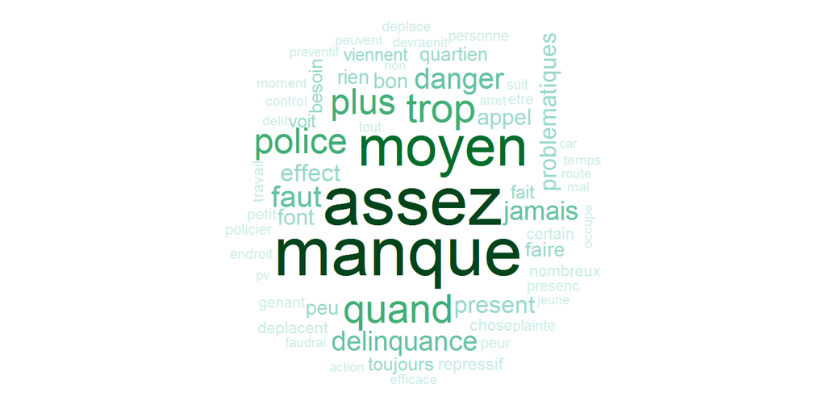

```r
wordcloud(d$word, d$freq, min.freq=70,color=pal2,random.order=FALSE)
```

## Autres statistiques lexicales

Un certain nombre de statistiques (*lexicométrie*) peuvent être calculées lors du bilan lexical : le nombre de termes total et distincts, le nombre de **hapax** (mots présents une seule fois dans le corpus), le nombre de mots longs.

Le pourcentage de termes distincts permet de mesurer la **variété du lexique** et le pourcentage de hapax permet de mesurer la **rareté du lexique** employé.

Enfin pourcentage de mots longs donne une idée (approximative) de la **complexité** du lexique employé.

Toutes ces statistiques peuvent être facilement ventilées par variable.

Ce ne serait pas compliqué de le recoder en R

## Une fois le lexique terminé, on reconstruit la matrice

Une fois le lexique construit, les formes inutiles filtrées, on peut reconstruire le tableau lexical ou une de ses variantes en utilisant l'option `dictionary`.

```r
#myDtmFinal <- TermDocumentMatrix(myCorpus0, control = list(dictionary = dico))
```

La matrice qui décrit les textes sous la forme de vecteurs numériques, permettant de faire les statistiques réalisées jusqu'à présent, permet également d'utiliser des techniques traditionnelles de data-mining ou d'intégrer les forms en tant que variables au sein d'un modèle.

## Démonstration avec r.temis

[figure not shown]

## Démonstration avec r.temis

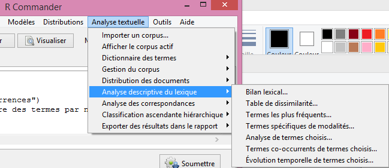

## Démonstration avec r.temis

[figure not shown]

## Démonstration avec r.temis

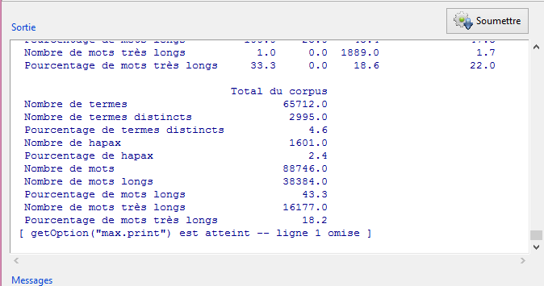

## Démonstration avec Iramuteq

[figure not shown]

## Démonstration avec Iramuteq

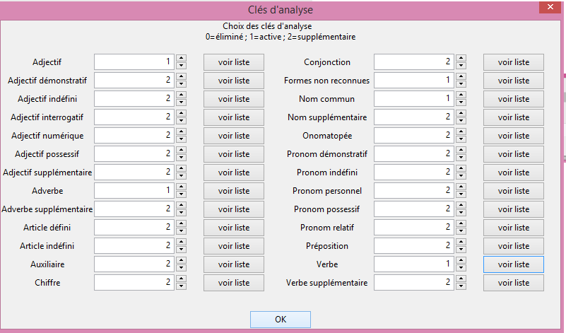

## Démonstration avec Iramuteq

[figure not shown]

## Outils clé en main

- Ils permettent de facilement réaliser le prétraitement sur données françaises (**lemmatisation** sur dictionnaire plutôt que stemming, reconnaissance des mots composés comme "grand-père" pour Iramuteq, étiquettes grammaticales), et de personnaliser certaines étapes (lemmatisation différenciée par exemple).
- Ils permettent de gérer les gros textes (en les décomposant en segments)
- un certain nombre de statistiques (*lexicométrie*) citées précédemment sont automatiquement calculées
- Sont disponibles les méthodes statistiques (analyse factorielle ou Classification), la visualisation de données textuelles (Nuage de mots) ou l'analyse de réseaux de mots pour Iramuteq (Analyses de similitudes).

## Contraignants (iramuteq)

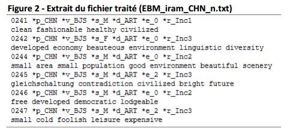

## Contraignants (iramuteq)

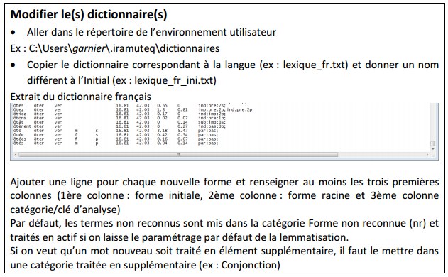

## Classement de documents et identification de thèmes

## Méthodes de classement

Une fois le pré-traitement effectué, on peut vouloir regrouper les documents en fonction des thématiques **latentes** abordées, et/ou vouloir vouloir classer les thèmes abordés sur l'ensemble du corpus..

On peut utiliser diverses techniques de **classifications** non propres aux données textuelles (**CAH**, **kmeans**) qui s'appuient sur des matrices de dissimilarités calculées à partir des matrices documents x termes ou termes x documents **pour une pondération choisie**.

Une autre approche consiste à s'appuyer sur des **modèles de génération des données** (**topic modeling**) pour exhiber la structure sémantique latente du document (**LSA**, **LDA**).

L'analyse des termes qui découle de ces classements peut être un moyen de réduire à nouveau le lexique (en ne gardant que les termes les plus représentatifs d'un thème par exemple).

## La CAH

Une fois la matrice de pondération calculée, on implémente une matrice de dissimalité entre les documents. On applique ensuite un algorithme itératif, partant d'un point où les clusters sont des singletons (les documents) et fusionnant les classes deux par deux de sorte à minimiser la variance intra-classe. La prise en compte de covariables de pose pas de problème.

En analyse textuelle, le lexique décrivant les document pouvant être très important, la distance est mesurée dans un très grand espace. Pour cette raison on tend à utiliser la **similarité cosinus** plutôt que la distance euclidienne.

Les exemples qui suivent sont construits sur un corpus de réponses à une question portant sur l'opinion des enquêtés au sujet de la police.

## La CAH, thématiques du corpus

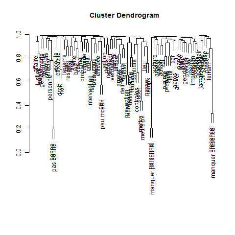

## Projection sur les composantes principales

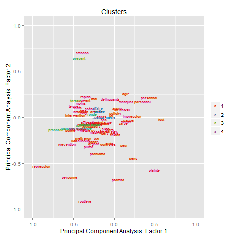

## CAH sur les documents et thèmes abordés dans les classes

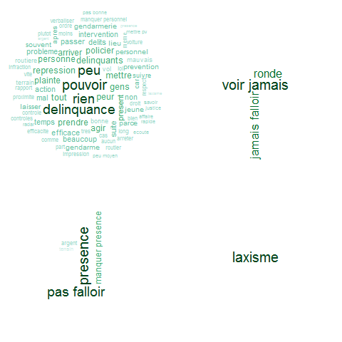

## CAH avec r.temis

L'analyse est réalisée en deux temps. Une première étape permet de créer et d'afficher le dendrogramme ; une seconde de déterminer le nombre de classes choisi et de les interpréter.

L'utilisateur peut fixer le niveau de rareté des termes conservés dans l'analyse.

La distance du Khi2 est utilisée entre les documents et ceux-ci sont rapprochés par la méthode de Ward.

La classification est réalisée sur le tableau lexical entier.

## CAH avec r.temis

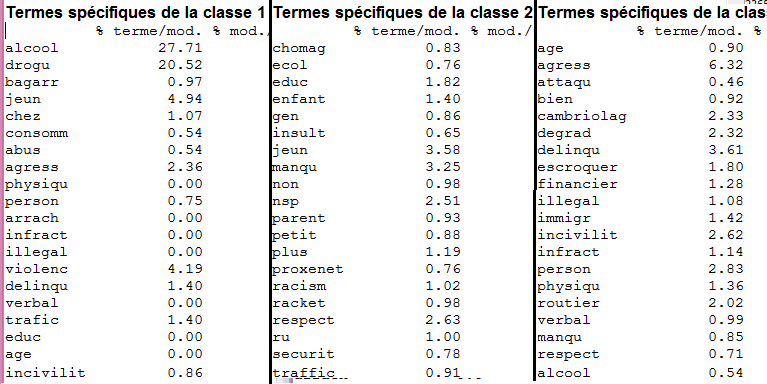

Il est possible de compléter cette analyse par une analyse des correspondances.

## Classification de Reinert avec Iramuteq

Sur la matrice binaire (présence du mot dans le texte ou non), une classification descendante hiérarchique regroupe des documents en classes, ou **mondes lexicaux** différenciés par la distribution de leur vocabulaire.

Les énoncés d'une même classe sont similaires entre eux, et aussi différents que possible des énoncés d'une autre classe.

La classification descendante hiérarchique est particulièrement adaptée pour des tableaux comportant une très forte proportion de zéros.

## Les K-means ou centres mobiles

Pour confirmer l'analyse hiérarchique (ou aussi parce que cet algorithme est moins exigeant en temps de calcul car ne nécessite pas le calcul de la matrice de dissimilarité), on peut appliquer les **k-means**. L'algorithme étant fondé sur la distance euclidienne, il faut commencer par **normaliser la matrice TF-IDF**.

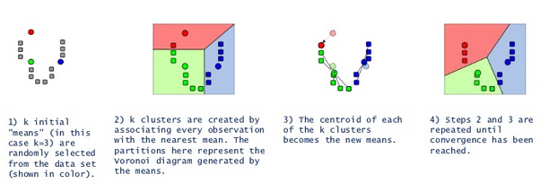

L'algorithme démarre avec une allocation aléatoire de centres, et à chaque itération les documents sont alloués au centre le plus proche avant que les centres soient recalculés en tant que centre de gravité des classes ainsi constituées. On poursuit jusqu'à stabilité.

## Projection sur les composantes principales

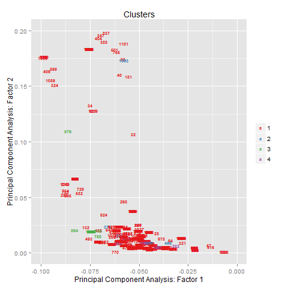

## Thèmes abordés dans les classes

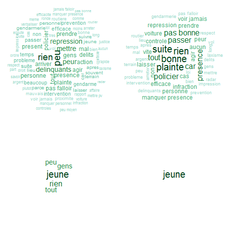

## Remarque : partition around medoids théoriquement plus robuste

Principe général : On définit k objets représentatifs des classes, appelés médoïdes, situés au centre des classes. Le médoïde est l'objet pour lequel la dissimilarité moyenne par rapport aux autres objets de la classe est la plus faible.

Le premier médoïde est l'objet minimisant la fonction objective distance moyenne de l'objet au reste, le second médoïde est le 2e objet minimisant la même fonction objective. On détermine ainsi les k premiers médoïds. Chaque objet est ensuite affecté au groupe dont le médoïde est le plus proche. Pour tout couple d'objet (i,j) tel que i soit un des k médoïdes et j un autre objet, on permute i et j si la fonction objective baisse. On répéte l'étape précédente jusqu'à stabilisation de la partition.

## Les K-means sphériques sur les documents

Algorithme proposé en 2001, il serait plus approprié pour les données textuelles car ferait appel à la similarité cosinus.

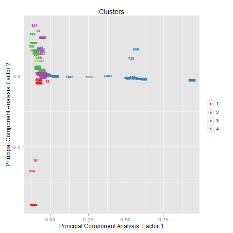

## Thèmes abordés dans les classes

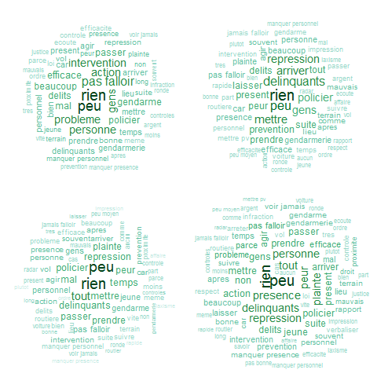

## Les K-means sphériques sur les termes

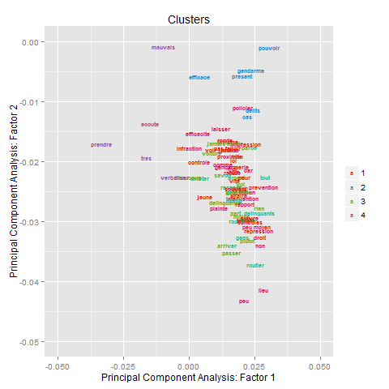

## LSA, définition

**Latent Semantic Analysis** est avant tout un méthode de représentation des documents (changement de base) qui permet de faire ressortir des relations sémantiques entre les termes, découvre des schémas d'association entre mots. Elle permet de ce fait d'atténuer les problèmes de synonymie et polysémie

En pratique, c'est une technique d'algèbre linéaire reposant sur la **décomposition en valeurs propres** (SVD) de la matrice termes x documents (TF-IDF par exemple). Elle permet d'identifier k thèmes ou concepts, ou k est déterminé a posteriori (par exemple règle du coude), et peut donc être utilisée comme une **méthode de réduction de dimension** en offrant une représentation des documents et des termes dans un nouvel espace plus petit sur lequel on peut procéder à une nouvelle clusterisation si on le souhaite.

## LSA, illustration

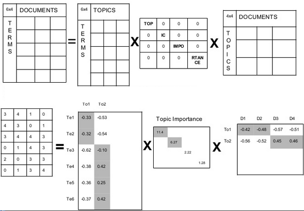

## Détection des thèmes

```r
require(lsa)
LSA <- lsa(tf_idf)
coord_doc <- LSA$dk %*% diag(LSA$sk)
coord_term <- LSA$tk %*% diag(LSA$sk)
require(proxy)
DIST = dist(coord_doc,method = "cosine")
HCLUST = hclust(DIST, method = "ward.D2")
plot(HCLUST)
clusters <- cutree(HCLUST, k = 2)
```

## CAH sur les termes

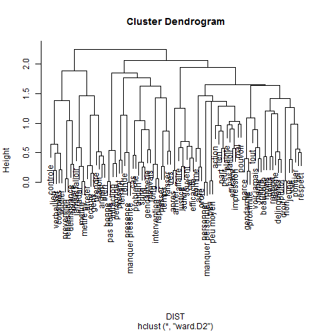

## Classement de documents

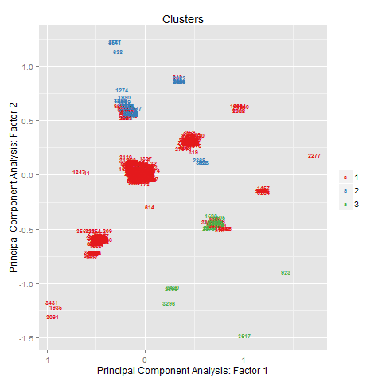

## L'approche probabiliste

Les thèmes sont caractérisés par une distribution associée aux mots courants d'une langue choisie.

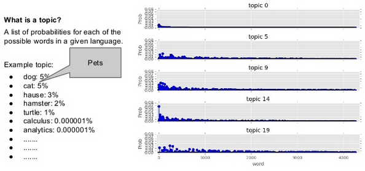

## Probabilistic Latent Semantic Analysis

Une approche probabiliste qui prolonge la LSA : chaque document est vu comme une **combinaison de thèmes**, eux-mêmes vus comme une **combinaison de mots**.

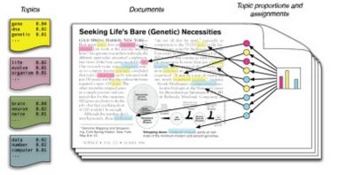

## Probabilistic Latent Semantic Analysis

Au lieu de trouver une représentation de faible rang, on essaie de trouver un mélange de distributions multinomiales avec \(P(mot|doc)=\sum_t P(theme|doc) P(mot|theme)\)

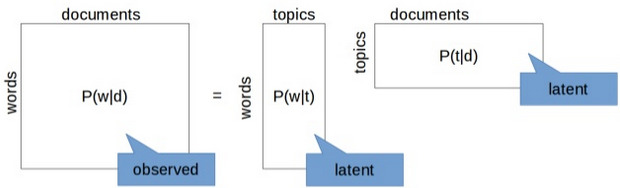

L'estimation se fait par l'algorithme EM. Le choix du nombre de thèmes peut être réalisé par sélection de modèles (plus complexe que pour LSA). La difficulté réside dans le fait qu'il faut trouver les distributions qui correspondent le mieux aux données tout en évitant le **surajustement** sachant que certains documents peuvent présenter de fortes associations pour un petit nombre de thèmes tandis que certains peuvent présenter une distribution plus homogènes.

## LDA, une approche bayésienne

Une extension de la PLSA dans laquelle on rajoute des **a priori** sur :

- le nombre de thèmes moyens par document (au lieu de choisir ex post le nombre de thèmes on fait une hypothèse sur le fait qu'il en a peu ou beaucoup)
- en moyenne comment les mots sont distribués selon les thèmes, ie est-ce que certains thèmes sont fortement associés à certains mots.

Rq : pour aller plus loin, CTM (Correlated topic model), STM (structural topic modeling) autorisant les covariables et la correlation entre thèmes, DTM (dynamic topic modeling)…

## LDA, illustration

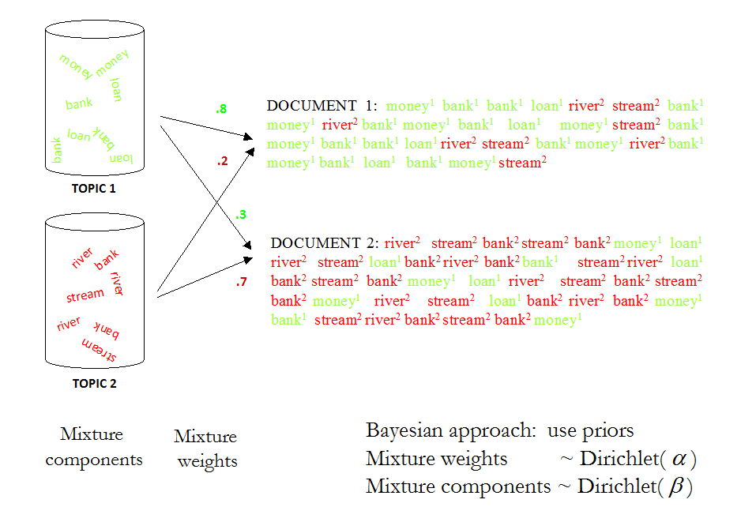

## Distribution de Dirichlet

On prend distribution de **Dirichlet** pour la probabilité d'un thème d'apparaître dans un document (respectivement un terme dans un thème), on peut donc paramétrer cette distribution en fonction de nos "a priori" sur les données. La valeur par défaut est 0.1

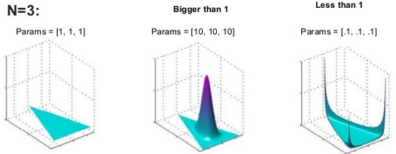

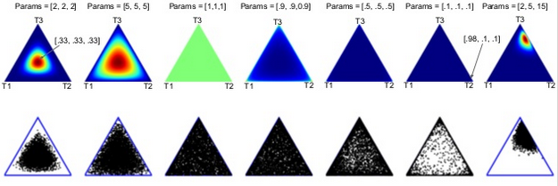